# Grouping Example

Nina Zumel, Nate Sutton

2018-11-05

This vignette shows an example use of *y*-stratified sampling with a grouping restriction in `vtreat`.

For this example, we will use the `Theosph` dataset: data from an experiment on the pharmacokinetics of theophylline. We will demonstrate the desired effects of *y*-stratification while also respecting a grouping constraint.

## The Data

First, let’s look at the data.

```r
# panel data for concentration in multiple subjects
d <- datasets::Theoph
head(d)
```

```
##   Subject   Wt Dose Time  conc
## 1       1 79.6 4.02 0.00  0.74
## 2       1 79.6 4.02 0.25  2.84
## 3       1 79.6 4.02 0.57  6.57
## 4       1 79.6 4.02 1.12 10.50
## 5       1 79.6 4.02 2.02  9.66
## 6       1 79.6 4.02 3.82  8.58
```

```r
summary(d)
```

```
##     Subject         Wt             Dose            Time
##  6      :11   Min.   :54.60   Min.   :3.100   Min.   : 0.000
##  7      :11   1st Qu.:63.58   1st Qu.:4.305   1st Qu.: 0.595
##  8      :11   Median :70.50   Median :4.530   Median : 3.530
##  11     :11   Mean   :69.58   Mean   :4.626   Mean   : 5.895
##  3      :11   3rd Qu.:74.42   3rd Qu.:5.037   3rd Qu.: 9.000
##  2      :11   Max.   :86.40   Max.   :5.860   Max.   :24.650
##  (Other):66
##       conc
##  Min.   : 0.000
##  1st Qu.: 2.877
##  Median : 5.275
##  Mean   : 4.960
##  3rd Qu.: 7.140
##  Max.   :11.400
##
```

We have twelve subjects, who each received a dose of the anti-asthma drug theophylline. The theophylline concentration in the patients’ blood was then measured at eleven points during the next 25 hours. Most of the patients got about the same dose, although the dose information reported in the dataset is normalized by weight.

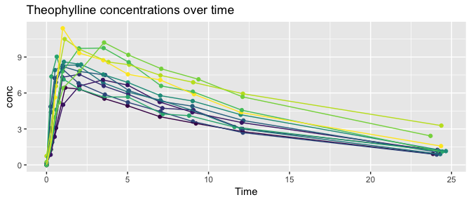

```r
if(have_ggplot) {
  ggplot(d, aes(x=Time, y=conc, color=Subject)) +
  geom_point() + geom_line() +
    theme(legend.position="none") +
    ggtitle("Theophylline concentrations over time")
}
```

## Partitioning the Data for Modeling

Suppose we wanted to fit a model to analyze how a patient’s weight affects how theophylline is metabolized, and validate that model with three-fold cross-validation. It would be important that all readings from a given patient stay in the same fold. We might also want the population in each fold to have similar distributions of theophylline concentrations curves.

Recall that the goal of *y*-stratification is to insure that all samples from the data have as close to identical *y* distributions as possible. This becomes more difficult when we also have to obey a grouping constraint.

Let’s look at three ways of splitting the data into folds. First, we will split the data arbitrarily into three groups, using the modulo of the Subject id to do the splitting.

```r
# a somewhat arbitrary split of patients
subnum = as.numeric(as.character(d$Subject))
d$modSplit = as.factor(subnum %% 3)
```

We can verify that this split preserves groups, by looking at the table of subject observations in each fold. Each subject should only appear in a single fold.

```r
print(table(Subject=d$Subject, groupid=d$modSplit))
```

```
##        groupid
## Subject  0  1  2
##      6  11  0  0
##      7   0 11  0
##      8   0  0 11
##      11  0  0 11
##      3  11  0  0
##      2   0  0 11
##      4   0 11  0
##      9  11  0  0
##      12 11  0  0
##      10  0 11  0
##      1   0 11  0
##      5   0  0 11
```

Now let’s try the standard *y* stratification in `vtreat`.

```r
# stratify by outcome only
# forces concentration to be equivalent
pStrat <- kWayStratifiedY(nrow(d),3,d,d$conc)
attr(pStrat, "splitmethod")
```

```
## [1] "kwaycrossystratified"
```

```r
d$stratSplit <- vtreat::getSplitPlanAppLabels(nrow(d),pStrat)

print(table(Subject=d$Subject, groupid=d$stratSplit))
```

```
##        groupid
## Subject 1 2 3
##      6  4 4 3
##      7  4 6 1
##      8  3 4 4
##      11 1 5 5
##      3  3 2 6
##      2  5 2 4
##      4  3 3 5
##      9  5 4 2
##      12 3 4 4
##      10 6 2 3
##      1  2 5 4
##      5  5 3 3
```

We can see this partition didn’t preserve the `Subject` grouping.

Finally, we can try `vtreat`’s group-preserving split, which also tries to *y*-stratify as much as possible (by stratifying on the mean *y* observation from each group).

```r
# stratify by patient and outcome
# allows concentration to vary amoung individual patients
splitter <- makekWayCrossValidationGroupedByColumn('Subject')
split <- splitter(nrow(d),3,d,d$conc)
attr(split, "splitmethod")
```

```
## [1] "kwaycrossystratifiedgrouped"
```

```r
d$subjectSplit <- vtreat::getSplitPlanAppLabels(nrow(d),split)

print(table(Subject=d$Subject, groupid=d$subjectSplit))
```

```
##        groupid
## Subject  1  2  3
##      6  11  0  0
##      7   0  0 11
##      8   0 11  0
##      11  0 11  0
##      3  11  0  0
##      2   0  0 11
##      4   0 11  0
##      9  11  0  0
##      12  0  0 11
##      10 11  0  0
##      1   0 11  0
##      5   0  0 11
```

This is again a subject-preserving partition.

We can compare the mean theophylline concentration and the average pharmacokinetic profile for each fold, for both of the subject-preserving partitions. We see that the stratification reduces some of the variation between folds.

### Arbitrary Partition

```
## [1] "Arbitrary grouping"
## [1] "Group means:"
##        0        1        2
## 4.728864 5.305227 4.847273
## [1] "Standard deviation of group means: 0.304395061237506"
```

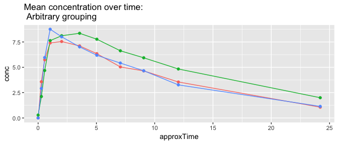

### Group-preserving, *y*-stratified Partition

```
## [1] "Group by patient, stratify on y"
## [1] "Group means:"
##        1        2        3
## 4.859091 5.040455 4.981818
## [1] "Standard deviation of group means: 0.0925499641694611"
```

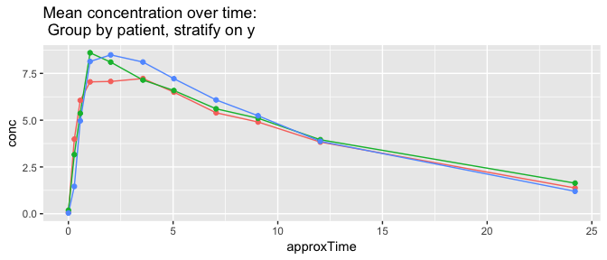